# Mr.Blacks.Bot Analysis

Jianghanhan Li

4/20/2017

### Objectives

###### • Figure out how the TV show Mr.Blacks.Bot is performing, in terms of ratings and other broad patterns

###### • Test hypothesis - if some creative decisions at the end of the first Season 1 was a primary driver of weaker ratings in the Season 2

###### • Any counterintuitive findings, on the scheduling of the show or the commercials

#### 1. Data Wrangling

```r
stopifnot(require(dplyr))
stopifnot(require(tidyr))
stopifnot(require(broom))
```

```r
stopifnot(require(ggplot2))
# choose mxm.csv in your folder
# mxm <- read.csv(file.choose(), header = TRUE)
mxm <- read.csv("~/Dropbox/Career/NBCU/mxm.csv", header = TRUE)
str(mxm)
```

```
## 'data.frame':    2088 obs. of  9 variables:
##  $ X                   : int  0 1 2 3 4 5 6 7 8 9 ...
##  $ Network             : Factor w/ 1 level "DKN": 1 1 1 1 1 1 1 1 1 1 ...
##  $ Date                : Factor w/ 35 levels "2015-09-21","2015-09-28",..: 1 1 1 1 1 1 1 1 1 1 ...
##  $ Time                : Factor w/ 120 levels "08:00 PM","08:01 PM",..: 61 62 63 64 65 66 67 68 69 70 ...
##  $ Program             : Factor w/ 1 level "BLACK_S_BOT": 1 1 1 1 1 1 1 1 1 1 ...
##  $ Length              : int  60 60 60 60 60 60 60 60 60 60 ...
##  $ Rating              : num  3.74 3.53 3.54 3.48 3.39 ...
##  $ Minute_In_Commercial: int  0 0 0 0 0 0 0 0 0 0 ...
##  $ Total_Loss_perc     : num  15.64 5.97 6.5 5.26 3.37 ...
```

```r
# chooseseasonal_telecast_ratings.csv in your folder
# season <- read.csv(file.choose(), header = TRUE)
season <- read.csv("~/Dropbox/Career/NBCU/seasonal_telecast_ratings.csv", header = TRUE)
str(season)
```

```
## 'data.frame':    4598 obs. of  10 variables:
##  $ X                 : int  0 1 2 3 4 5 6 7 8 9 ...
##  $ show_name         : Factor w/ 180 levels "","ABLED","ACROBATIC RACE",..: 120 120 120 120 120 120 120 120 120 120 ...
##  $ network           : Factor w/ 4 levels "DKN","JGBC","JGN",..: 3 3 3 3 3 3 3 3 3 3 ...
##  $ genre             : Factor w/ 4 levels "Animation","Comedy",..: 3 3 3 3 3 3 3 3 3 3 ...
##  $ time_slot         : Factor w/ 2212 levels "2015-09-01 20:00:00",..: 75 76 102 133 164 196 226 254 280 311 ...
##  $ program_start_time: Factor w/ 2583 levels "2015-09-01 20:00:00",..: 93 95 123 158 192 230 264 295 325 362 ...
##  $ program_duration  : int  3600 7200 3600 3600 3600 3600 3600 3600 3600 7200 ...
##  $ show_premier      : int  0 0 1 0 0 0 0 0 0 0 ...
##  $ show_repeat       : int  1 1 0 0 0 0 0 0 0 0 ...
##  $ rating            : num  0.00678 0.00512 0.02176 0.01866 0.01688 ...
```

```r
# split date and time
season$date <- as.Date(season$time_slot)
season$time <- format(as.POSIXct(season$time_slot), format = "%H:%M")

# change the rating to the same unit as the rating in mxm.csv
season$rating_new <- season$rating*100
season$duration <- season$program_duration/60
```

#### 2. Exploratory Analysis

##### Mr.Blakcs.Bot performance in DKN network

```r
summary(mxm)
```

```
##        X          Network            Date            Time
##  Min.   :   0.0   DKN:2088   2015-09-21:  60   10:01 PM:  24
##  1st Qu.: 521.8              2015-09-28:  60   10:02 PM:  24
##  Median :1043.5              2015-10-05:  60   10:03 PM:  24
##  Mean   :1043.5              2015-10-12:  60   10:04 PM:  24
##  3rd Qu.:1565.2              2015-10-19:  60   10:05 PM:  24
##  Max.   :2087.0              2015-10-26:  60   10:06 PM:  24
##                              (Other)   :1728   (Other) :1944
##         Program         Length          Rating      Minute_In_Commercial
##  BLACK_S_BOT:2088   Min.   :59.00   Min.   :0.955   Min.   :0.0000
##                     1st Qu.:59.00   1st Qu.:1.372   1st Qu.:0.0000
##                     Median :60.00   Median :1.552   Median :0.0000
##                     Mean   :59.66   Mean   :1.706   Mean   :0.3472
##                     3rd Qu.:60.00   3rd Qu.:1.964   3rd Qu.:1.0000
##                     Max.   :60.00   Max.   :3.831   Max.   :1.0000
##
##  Total_Loss_perc
##  Min.   : 0.000
##  1st Qu.: 1.776
##  Median : 2.548
##  Mean   : 3.417
##  3rd Qu.: 3.824
##  Max.   :29.634
##
```

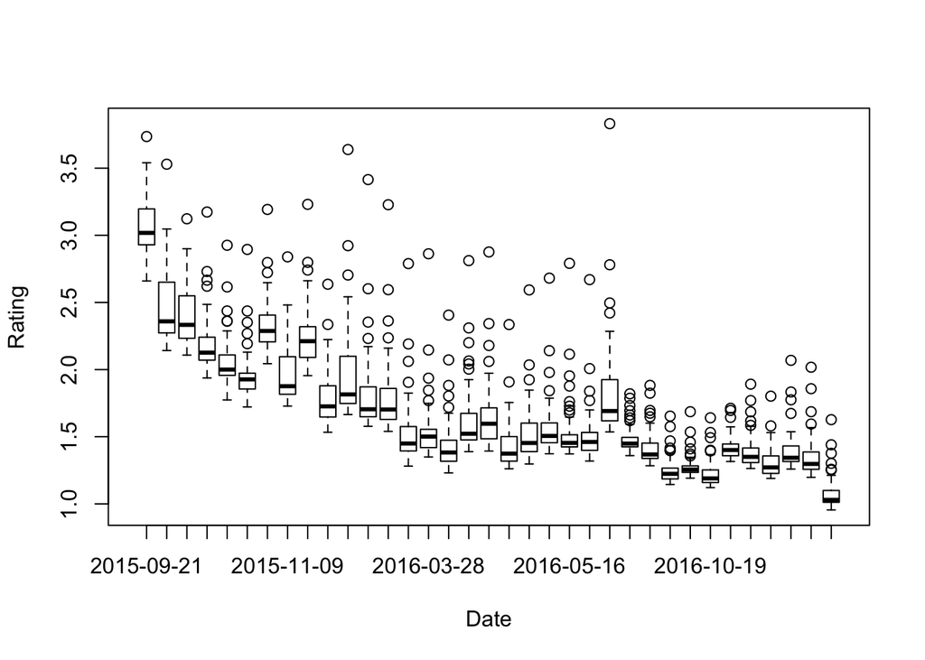

```r
plot(mxm$Date, mxm$Rating, xlab = "Date", ylab = "Rating")
```

From above, we see the broad trend for the *rating*. In Season 1, between Sep 21, 2015 and May 23, 2016, the median values of rating were declining, from slightly above 3 to slightly below 1.5. However, at the end of Season 1, around May 23, 2016, the median value of rating increased evidently to above 1.5. In the last episode of season 1, the rating in those 60 mins, is of high variance, as the interquantile range is quite wide and there are quite a few outliers, one of which goes above 3.5. This suggests that there is a wide range of reactions regarding the ending of the show. During the 60 mins of the Season 1 finale show, at some points in time, there were a lot of people watching, (the above 3.5 ratings), and at some other points in time, there were very few people watching.

Since the begining of season 2, the median ratings in general stayed below 1.5. It seems the producer’s hypothesis that the creative decisions at the end of season 1 lead to low Season 2 ratings, made some sense.

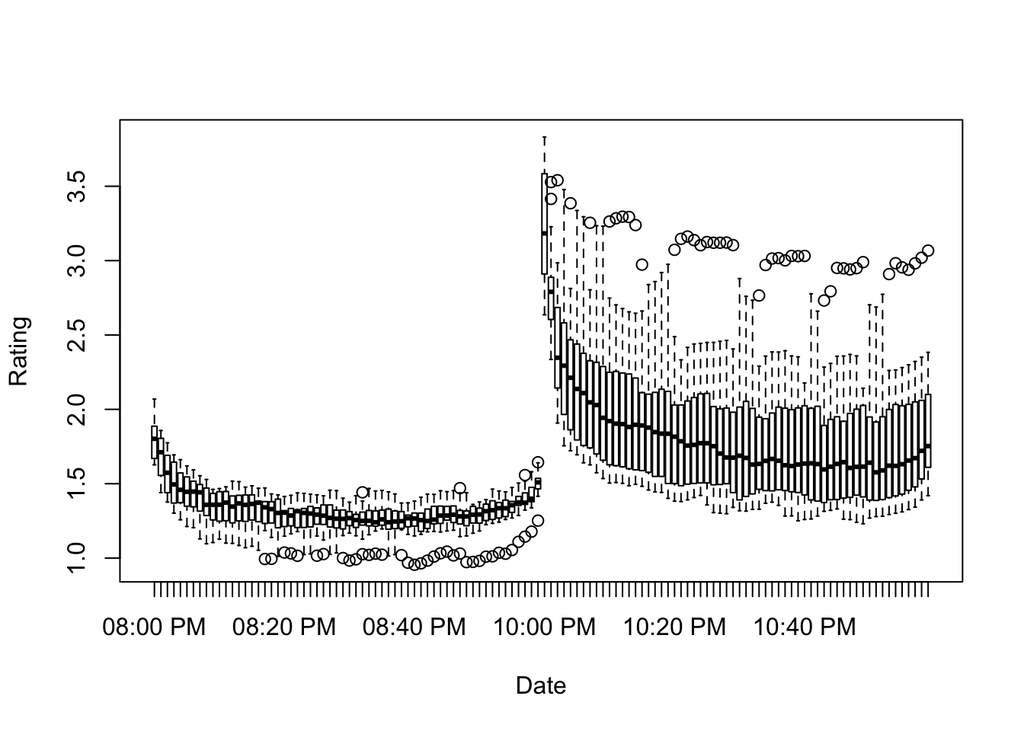

```r
plot(mxm$Time, mxm$Rating, xlab = "Date", ylab = "Rating")
```

From the above plot, we also see that overall, the ratings for Season 1 where all the episodes were aired between 10 pm to 11 pm, were higher than the ratings for Season 2 where almost all of the episodes were aired between 8 pm to 9 pm.

##### Scheduling

Scheduling plays a very significant role in TV ratings. Mr. Bl@ck.s.bot changed its time between seasons, from Season 1 aired at 10 pm to Season 2 aired at 8 pm.

So how much of the change in ratings is potentially due to scheduling of the show. We could find this out by comparing Mr.Blacks.Bot with other shows, especially shows of the same genre, drama, that were aired during the same period in other networks.

Specifically, does 10 pm dramas perform better than 8 pm dramas ?

```r
summary(season)
```

```
##        X                            show_name    network
##  Min.   :   0   LOWEST COMMON DENOMINATOR:  97   DKN : 869
##  1st Qu.:1149   BACKYARD LOT             :  93   JGBC:1413
##  Median :2298   SING YOUR SOCKS OFF      :  88   JGN :1226
##  Mean   :2298   YOU'RE FIRED             :  87   PNN :1090
##  3rd Qu.:3448   CRIME PAYS               :  78
##  Max.   :4597   BLACK IN AMERICA         :  73
##                 (Other)                  :4082
##        genre                    time_slot              program_start_time
##  Animation: 237   2015-09-01 20:00:00:   4   2015-09-01 20:00:00:   4
##  Comedy   :1309   2015-09-02 20:00:00:   4   2015-09-02 20:00:00:   4
##  Drama    :2038   2015-09-02 21:00:00:   4   2015-09-03 20:00:00:   4
##  Other    :1014   2015-09-03 20:00:00:   4   2015-09-04 20:00:00:   4
##                   2015-09-04 20:00:00:   4   2015-09-07 20:00:00:   4
##                   2015-09-07 20:00:00:   4   2015-09-08 20:00:00:   4
##                   (Other)            :4574   (Other)            :4574
##  program_duration  show_premier      show_repeat         rating
##  Min.   :  240    Min.   :0.00000   Min.   :0.0000   Min.   :0.001711
##  1st Qu.: 1800    1st Qu.:0.00000   1st Qu.:0.0000   1st Qu.:0.009592
##  Median : 3600    Median :0.00000   Median :0.0000   Median :0.015021
##  Mean   : 3239    Mean   :0.08286   Mean   :0.3084   Mean   :0.017389
##  3rd Qu.: 3600    3rd Qu.:0.00000   3rd Qu.:1.0000   3rd Qu.:0.023137
##  Max.   :10800    Max.   :1.00000   Max.   :1.0000   Max.   :0.063658
##
##       date                time             rating_new        duration
##  Min.   :2015-09-01   Length:4598        Min.   :0.1711   Min.   :  4.00
##  1st Qu.:2016-01-11   Class :character   1st Qu.:0.9592   1st Qu.: 30.00
##  Median :2016-05-04   Mode  :character   Median :1.5021   Median : 60.00
##  Mean   :2016-05-12                      Mean   :1.7389   Mean   : 53.99
##  3rd Qu.:2016-09-16                      3rd Qu.:2.3137   3rd Qu.: 60.00
##  Max.   :2017-01-24                      Max.   :6.3658   Max.   :180.00
##
```

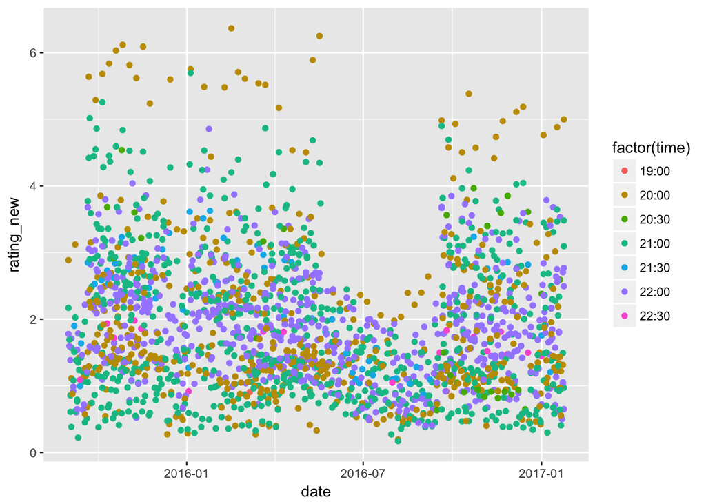

```r
# ten_pm_drama <- season %>% filter(time == "22:00" & genre == "Drama") %>% View()
# eight_pm_drama <- season %>% filter(time == "20:00" & genre == "Drama") %>% View()
drama <- season%>% filter(genre == "Drama")
ggplot(drama, aes(date, rating_new, colour = factor(time))) + geom_point()
```

From the above graph, we see that there is no systematic pattern that suggests dramas aired at 22:00 (purple dots) have high ratings than dramas aired at 20:00 pm (brown dots) in all four networks. Therefore, there isn’t enough evidence to support the claim that scheduling is a significant factor for low ratings in Season 2.

##### Commercials

How about commercials ? Commercials usually distract audiences and give them excuses to exit the shows. It also affects ratings.

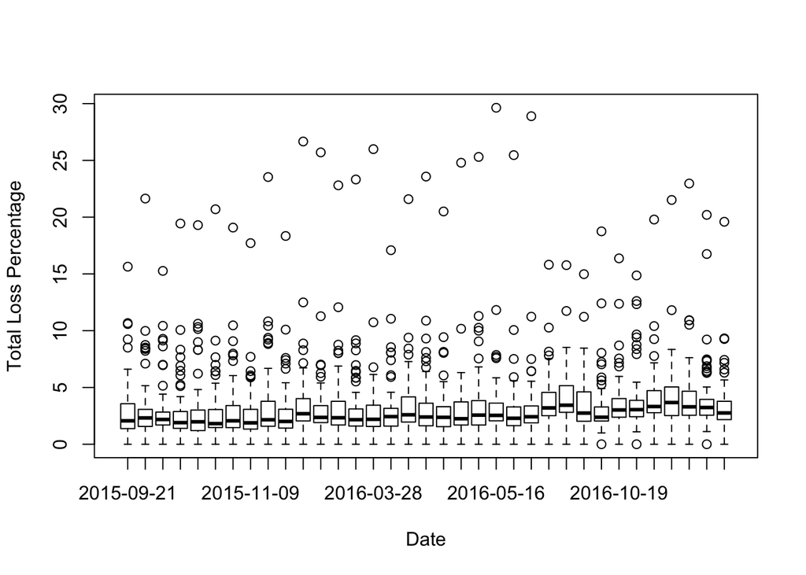

```r
plot(mxm$Date, mxm$Total_Loss_perc, xlab = "Date", ylab = "Total Loss Percentage")
```

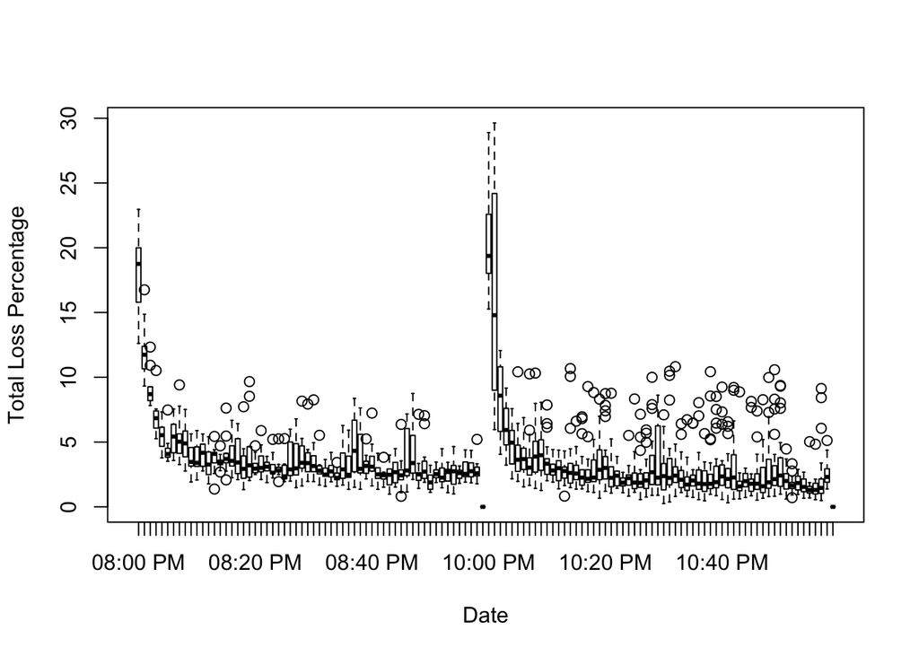

```r
plot(mxm$Time, mxm$Total_Loss_perc, xlab = "Date", ylab = "Total Loss Percentage")
```

The plots above reveal the *total_loss_percentage* across time, we see that the percentage of people who stopped watching TV at that minute stayed mostly constant during Season 1 (2015-09-21 to 2016-05-23), and increased slightly during Season 2 (2016-09-14 to 2017-01-18). The *total_loss_percentage* is mostly consistent with *rating* across time.

Now let’s see if we include commercials, how would the picture look like.

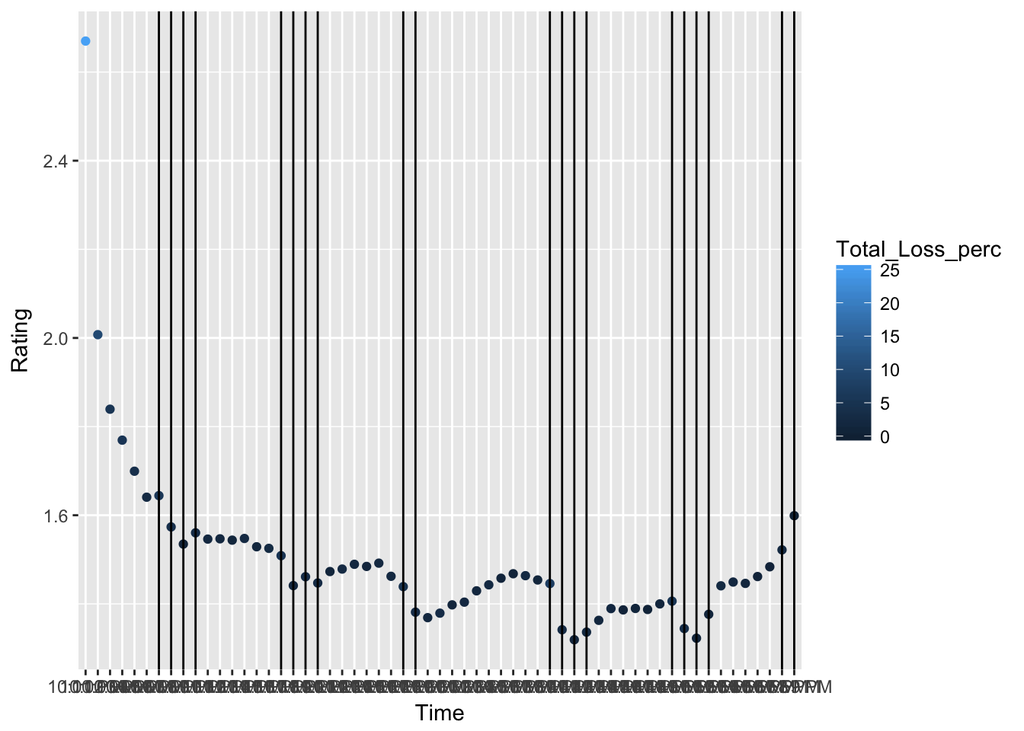

```r
S1_Final <- mxm %>% filter(Date == "2016-05-23")
ggplot(S1_Final, aes(x = Time, y = Rating)) + geom_point(aes(colour = Total_Loss_perc)) + geom_vline(xintercept = which(S1_Final$Minute_In_Commercial == 1))
```

From the graph above, we see that the ratings decreased substantially after the first few minutes of the season 1 final show. It seems whenever commercials were inserted, the ratings dropped further. The ratings would increase slowly after the commercials.

It’s worthy pointing out that there were moments between the commercials that the ratings already showed downward trend.

Is this pattern unique to the season 1 finale or not ? I plotted the same graphs to Season 1 episodes 1 to 3 to test it out.

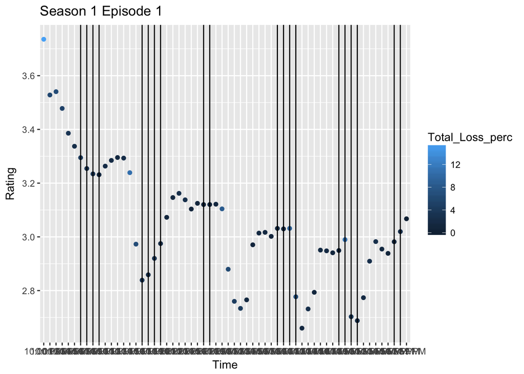

```r
S1_1 <- mxm %>% filter(Date == "2015-09-21")
ggplot(S1_1, aes(x = Time, y = Rating)) + geom_point(aes(colour = Total_Loss_perc)) + geom_vline(xintercept = which(S1_Final$Minute_In_Commercial == 1)) + ggtitle("Season 1 Episode 1")
```

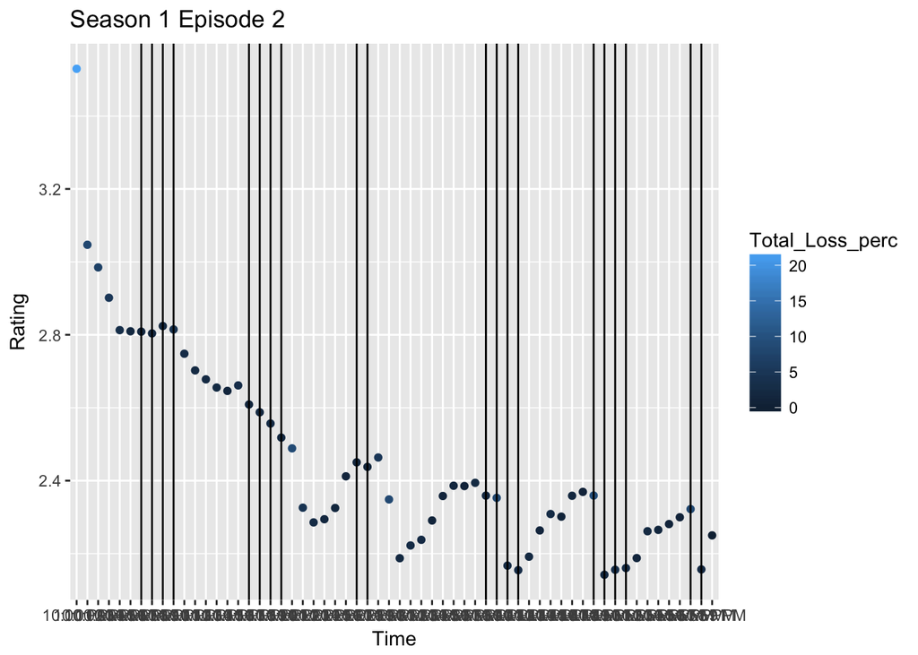

```r
S1_2 <- mxm %>% filter(Date == "2015-09-28")
ggplot(S1_2, aes(x = Time, y = Rating)) + geom_point(aes(colour = Total_Loss_perc)) + geom_vline(xintercept = which(S1_Final$Minute_In_Commercial == 1)) + ggtitle("Season 1 Episode 2")
```

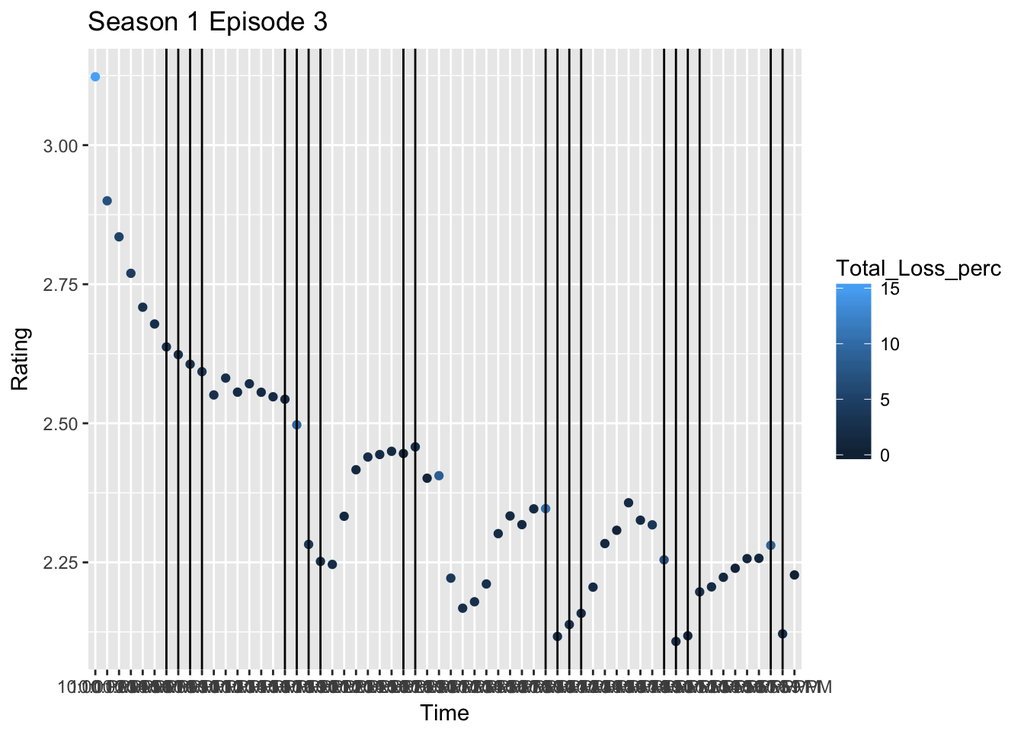

```r
S1_3 <- mxm %>% filter(Date == "2015-10-05")
ggplot(S1_3, aes(x = Time, y = Rating)) + geom_point(aes(colour = Total_Loss_perc)) + geom_vline(xintercept = which(S1_Final$Minute_In_Commercial == 1)) + ggtitle("Season 1 Episode 3")
```

The graphs above show that commercials do negatively affect ratings. However, it also reveals that ratings also oscillated when there was no commercials. So the ratings also response to the content of the show intrinsicaly.

#### 3. Next steps

This is an exploratory analysis. For the next steps, it’s worthy looking at it through a multivariate regression model to test the hypothesis, including a time series variable. It’s also worthiwhile to try the Difference in Differences method to further study the differential effect of a treatment, in this case, the commercials, on the ratings.